# R Notebook

Estuve mucho tiempo batallando con esto asi que me parece bueno documentar el proceso y el aprendizaje para futuras referencias porque no logre encontrar mucha informacion al respecto (esa fue una de las principales dificultades).

```r
library(tidyverse)
```

```r
#Load data
load('data/exp1_data.RData')
```

Genero el modelo.

```r
m.fit1 <- brm(update ~
            news * scoreOptimismo * ep +
            news * scoreAnsiedad * ep +
            news * pT +
            (1 | subj),
            data = dexp1,
            seed = 1234, # for reproducibility
            cores = 4, chains = 4,
            iter = 10000
            )
```

```
starting worker pid=110240 on localhost:11994 at 14:17:47.055
starting worker pid=110254 on localhost:11994 at 14:17:47.185
starting worker pid=110268 on localhost:11994 at 14:17:47.314
starting worker pid=110282 on localhost:11994 at 14:17:47.443
```

# Efectos

## Efecto de las noticias

La pregunta para responder es ¿Cual es el efecto del tipo de noticia sobre el update? (marginalizando los valores de las otras covariadas)

Hay dos maneras de calcularlo. Una es utilizando el paquete `brmsmargins`.

```r
library(brmsmargins)
```

Usamos la funcion `brmsmargins` y aclaramos que queremos el efecto marginal del tipo de noticias con el argumento `at` y ajustando el contraste para hacer la comparacion. A su vez obtenemos el highest density interval del 95% de la posterior para cada estimacion de efecto.

```r
news_effect <- brmsmargins(
  m.fit1,
  at = data.frame(news = c('good', 'bad')),
  contrasts = cbind('AME news' = c(-1,1)),
  effects = "integrateoutRE", k = 100L, seed = 1234,
  CI = 0.95, CIType = "HDI"
)

news_effect$Summary
```

| M | Mdn | LL | UL | PercentROPE | PercentMID | CI | CIType | ROPE | MID |
| --- | --- | --- | --- | --- | --- | --- | --- | --- | --- |
| 0.15590241 | 0.15588522 | 0.13773683 | 0.1741860 | NA | NA | 0.95 | HDI | NA | NA |
| 0.09985869 | 0.09983285 | 0.07832004 | 0.1213449 | NA | NA | 0.95 | HDI | NA | NA |

Otra manera de calcular lo mismo es utilizando el paquete `marginaleffects`.

```r
library(marginaleffects)
```

En este caso generamos predicciones con la funcion `predictions`. Las predicciones las hacemos sobre nuevos valores de random effects es decir con sujetos/datos que el modelo nunca vio. De esta manera se samplean de la distribucion poblacional de efectos random. Los sampleos se hacen sobre la distribucion posterior de la esperanza condicional usando la funcion `posterior_epred`.

```r
predictions(
    m.fit1,
    newdata = datagrid(news = c('good','bad'), subj = -1:-10),
    allow_new_levels = TRUE,
    sample_new_levels = "gaussian")
```

| Estimate | 2.5 % | 97.5 % | scoreOptimismo | ep | scoreAnsiedad | pT | news | subj |
| --- | --- | --- | --- | --- | --- | --- | --- | --- |
| 0.1552 | 0.0802 | 0.232 | 18.6 | 0.233 | 26.7 | 0.303 | good | -1 |
| 0.1552 | 0.0791 | 0.230 | 18.6 | 0.233 | 26.7 | 0.303 | good | -2 |
| 0.1553 | 0.0807 | 0.231 | 18.6 | 0.233 | 26.7 | 0.303 | good | -3 |
| 0.1549 | 0.0799 | 0.231 | 18.6 | 0.233 | 26.7 | 0.303 | good | -4 |
| 0.1557 | 0.0813 | 0.230 | 18.6 | 0.233 | 26.7 | 0.303 | good | -5 |
| 0.1554 | 0.0800 | 0.230 | 18.6 | 0.233 | 26.7 | 0.303 | good | -6 |
| 0.1558 | 0.0807 | 0.231 | 18.6 | 0.233 | 26.7 | 0.303 | good | -7 |
| 0.1558 | 0.0808 | 0.231 | 18.6 | 0.233 | 26.7 | 0.303 | good | -8 |
| 0.1551 | 0.0798 | 0.231 | 18.6 | 0.233 | 26.7 | 0.303 | good | -9 |
| 0.1550 | 0.0822 | 0.228 | 18.6 | 0.233 | 26.7 | 0.303 | good | -10 |

[output cut: 10 more lines]

```
Prediction type:  response
Columns: rowid, type, estimate, conf.low, conf.high, update, scoreOptimismo, ep, scoreAnsiedad, pT, news, subj
```

Para imitar el resultado obtenido con el paquete `brmsmargins` tenemos que promediar las estimaciones para cada tipo de noticia. Podemos hacerlo usango el argumento `by` dentro de la misma funcion.

```r
predictions(
    m.fit1,
    newdata = datagrid(news = c('good','bad'), subj = -1:-10),
    allow_new_levels = TRUE,
    sample_new_levels = "gaussian",
    by = 'news')
```

| news | Estimate | 2.5 % | 97.5 % |
| --- | --- | --- | --- |
| bad | 0.098 | 0.0671 | 0.130 |
| good | 0.156 | 0.1263 | 0.185 |

```
Prediction type:  response
Columns: type, news, estimate, conf.low, conf.high
```

Comparando los resultados del paquete `brmsmargins` con los del paquete `marginaleffects` los resultados son muy similares.

```r
news_effect$ContrastSummary
```

| M | Mdn | LL | UL | PercentROPE | PercentMID | CI | CIType | ROPE | MID | Label |
| --- | --- | --- | --- | --- | --- | --- | --- | --- | --- | --- |
| -0.05604372 | -0.05603573 | -0.0791476 | -0.03430368 | NA | NA | 0.95 | HDI | NA | NA | AME news |

```r
avg_comparisons(
    m.fit1,
    newdata = datagrid(firm = -1:-100),
    allow_new_levels = TRUE,
    sample_new_levels = "gaussian", variables = 'news')
```

| Term | Contrast | Estimate | 2.5 % | 97.5 % |
| --- | --- | --- | --- | --- |
| news | good - bad | 0.0575 | 0.0349 | 0.0798 |

```
Prediction type:  response
Columns: type, term, contrast, estimate, conf.low, conf.high
```

El mismo resultado podemos obtenerlo con la funcion `avg_slopes`.

```r
avg_slopes(m.fit1, variables = c('news'))
```

| Term | Contrast | Estimate | 2.5 % | 97.5 % |
| --- | --- | --- | --- | --- |
| news | good - bad | 0.056 | 0.0336 | 0.0785 |

```
Prediction type:  response
Columns: type, term, contrast, estimate, conf.low, conf.high
```

Mas alla del signo (que no tiene importancia) los valores absolutos son muy similares lo cual indica buena convergencia.

Podemos ahora graficar los resultados.

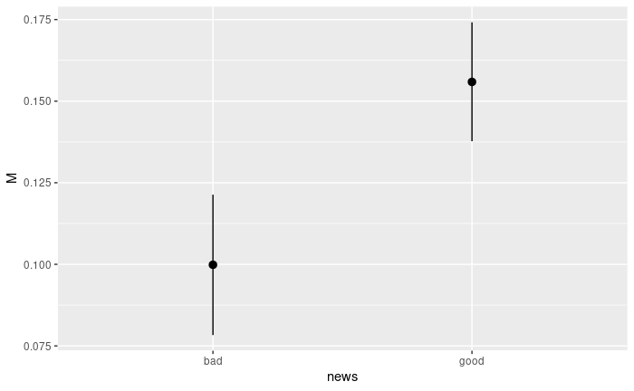

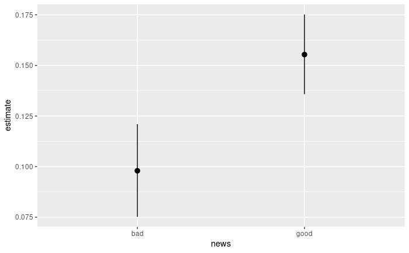

## Prediction Error

Primero calculamos el efecto (la derivada parcial de la pendiente) del prediction error para los dos tipos de noticias.

```r
avg_slopes(m.fit1, newdata = datagrid(news = c('good','bad'), subj = -1:-10),
    allow_new_levels = TRUE,
    sample_new_levels = "gaussian",
    variables = c("ep"), by = c('news'))
```

| Term | Contrast | news | Estimate | 2.5 % | 97.5 % |
| --- | --- | --- | --- | --- | --- |
| ep | mean(dY/dX) | good | 0.722 | 0.655 | 0.789 |
| ep | mean(dY/dX) | bad | 0.412 | 0.293 | 0.530 |

```
Prediction type:  response
Columns: type, term, contrast, news, estimate, conf.low, conf.high, predicted, predicted_hi, predicted_lo, tmp_idx
```

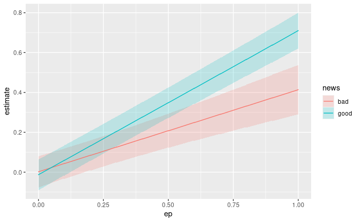

## Optimismo

Primero calculamos el efecto (la derivada parcial de la pendiente) sobre el optimismo para los dos tipos de noticias.

```r
avg_slopes(m.fit1, newdata = datagrid(news = c('good','bad'), subj = -1:-10),
    allow_new_levels = TRUE,
    sample_new_levels = "gaussian",
    variables = c("scoreOptimismo"), by = c('news'))
```

| Term | Contrast | news | Estimate | 2.5 % | 97.5 % |
| --- | --- | --- | --- | --- | --- |
| scoreOptimismo | mean(dY/dX) | good | 0.00211 | -0.00439 | 0.00870 |
| scoreOptimismo | mean(dY/dX) | bad | -0.01204 | -0.01913 | -0.00534 |

```
Prediction type:  response
Columns: type, term, contrast, news, estimate, conf.low, conf.high, predicted, predicted_hi, predicted_lo, tmp_idx
```

Graficamos

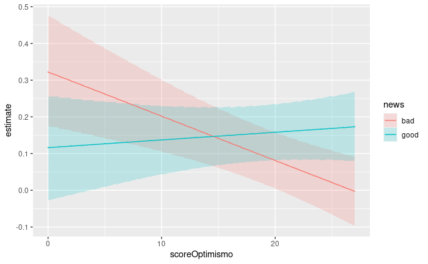

Diferencia en la pendiente segun valor de prediction error por tipo de noticia

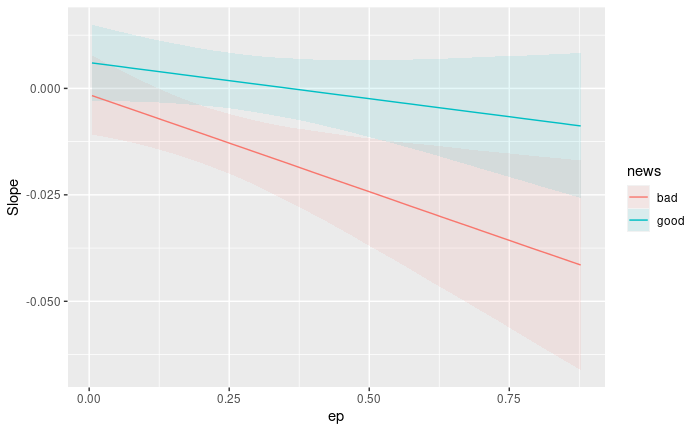

## Ansiedad

```r
avg_slopes(m.fit1, newdata = datagrid(news = c('good','bad'), subj = -1:-10),
    allow_new_levels = TRUE,
    sample_new_levels = "gaussian",
    variables = c("scoreAnsiedad"), by = c('news'))
```

| Term | Contrast | news | Estimate | 2.5 % | 97.5 % |
| --- | --- | --- | --- | --- | --- |
| scoreAnsiedad | mean(dY/dX) | good | 0.00799 | 0.00384 | 0.012154 |
| scoreAnsiedad | mean(dY/dX) | bad | -0.00342 | -0.00765 | 0.000721 |

```
Prediction type:  response
Columns: type, term, contrast, news, estimate, conf.low, conf.high, predicted, predicted_hi, predicted_lo, tmp_idx
```

Graficamos

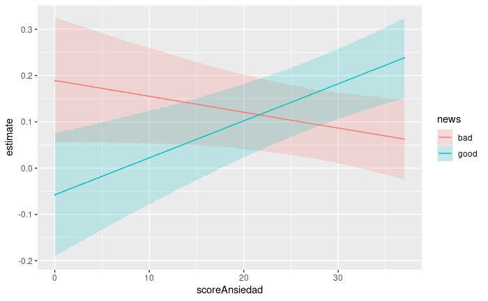

Diferencia en la pendiente segun valor de prediction error por tipo de noticia

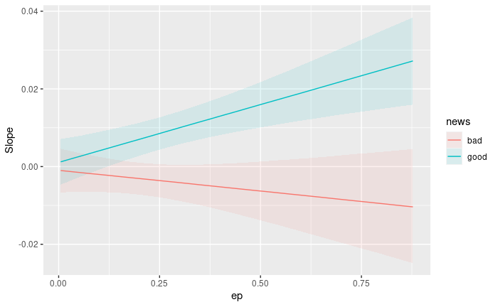

```r
avg_slopes(
    m.fit1,
    newdata = datagrid(news = c('good','bad'), subj = -1:-10, ep = seq(0,1,0.1)),
    allow_new_levels = TRUE,
    sample_new_levels = "gaussian", variables = 'scoreAnsiedad', by = 'news')
```

[output not shown]